# Visualizations of Airbnbs in New York City

Cho Laam Yuen

3/8/2022

# Overall Location

This map is a simple plot of all the Airbnbs in the New York City area. I decided to make an interactive map (can be zoomed) because the city area is small compared to the amount of Airbnbs (~50,000) in the city. To avoid over plotting in the boroughs such as Manhattan, I made it so that viewers can zoom in to see where Airbnbs are located in more detail.

[interactive chart not shown]

This is a choropleth map that shows the density of Airbnbs in New York City neighborhoods. I decided to make this map interactive as well (can be zoomed) so that the labeled neighborhoods can be clearly read.

[interactive chart not shown]

# Renting out an apartment vs.permanent rentals

I decided to create a simple bar chart to show the number of sporadically available, semi-permanent, and permanent Airbnb rentals in the 5 boroughs. This first visualization provides an overview of the annual availability of the Airbnbs. For the second visualization, I decided to provide a closer look at what neighborhoods these 3 categories of Airbnbs lie. It is interesting to note that the sporadic rental choropleth map looks quite similar to the density map in the previous question.

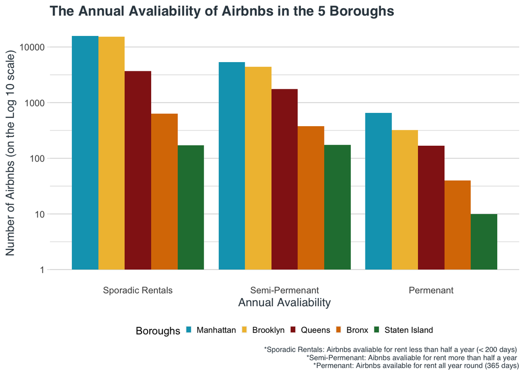

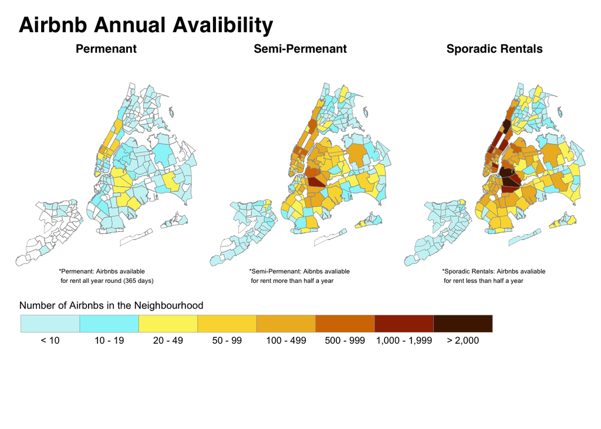

The table below presents 5 pieces of information that can be sorted and interacted with. By default it is sorted by a host’s total number of listings. This table is useful to explore questions such as whether hosts with more listings earn more money, where sorting by estimated average monthly income can provide an answer.

|  | Host ID | Host Name | Total Listings | Average Nightly Price | Estimated Average Monthly Income |
| --- | --- | --- | --- | --- | --- |
| 1 | 12243051 | Sonder | 1108 | $193 | $562,222 |
| 2 | 30283594 | Kara | 814 | $277 | $1,121,828 |
| 3 | 24831061 | Hosteeva LLC | 695 | $280 | $68,164 |
| 4 | 30787515 | Brooke | 640 | $399 | $12,136 |
| 5 | 107434423 | Blueground | 593 | $316 | $2,123,600 |
| 6 | 95459395 | Bluebird | 528 | $577 | $316,120 |
| 7 | 156158778 | Sally | 488 | $2,572 | $1,877,742 |
| 8 | 9419684 | Mike | 441 | $318 | $29,048 |
| 9 | 76104209 | Rated | 408 | $220 | $221,220 |
| 10 | 31214940 | Scott | 362 | $249 | $7,574 |

[output cut: 990 more lines]

# Top Reviewed Rentals

This interactive map presents the locations of the top 100 most expensive (in pink) and top 100 best reviewed (in blue) Airbnbs in the city. Users can zoom in on the map to take a closer look at the locations and upon hovering over the dots a tooltip with 5 additional pieces of information are shown (Host Name, Neighborhood, Review Score, Number of Reviews, and Price). The number 1 best reviewed and most expensive Airbnb are also highlighted by yellow disk on the map.

[interactive chart not shown]